# Random Forest Modeling of Exercise Quality

## Synopsis

In this report, I describe the methodology and results of a Random Forests model applied to a data set of personal exercise devices such as FitBit, Jawbone Up, and the Nike FuelBand. The data set was acquired from a Brazilian research team (http://groupware.les.inf.puc-rio.br/har) and includes 160 variables from 6 human subjects who performed a number of exercises and tests with belts, dumbbells, etc.

The objective was to create an accurate model of the quality of their exercise based on exercise device data. Exercise quality is categorized into one of 5 classes, named A-E. A is considered high quality exercise whereas the remaining classes are deficient in some way. The report below includes the following: -Exploratory analysis of the data set -Data cleaning and preparation -Creation of the training and test data sets -Cross validation and reporting out of sample error -Prediction of exercise quality for 20 separate subjects

### Data loading

```r
# Load required libraries
require(caret)
# open training data set
setwd("C:/OEB/Courses/Coursera/Materials/Practical Machine Learning")
data = read.csv("pml-training.csv", header = T)
# get dimensions of data set
dim(data)
```

```
## [1] 19622   160
```

```r
# read in testing data set
dataTest = read.csv("pml-testing.csv", header = T)
```

### Exploratory analysis and data cleaning

```r
# exploratory analysis
# get all values of classe, the key variable in this data set
unique(data$classe)
```

```
## [1] A B C D E
## Levels: A B C D E
```

```r
# Columns of numerical data as predictors and the outcome class (#160)
dataCols = c(8,9,10,46,47,48,84,85,86,122,123,124,160)

# do random forest model on the data set
temp = seq(1,19622,by=10)
temp2 = seq(2,19622,by=20)
train_sub = data[temp, dataCols]
test_sub = data[temp2,dataCols]

# verify that we are using only the most useful, numerical predictors
# for the model
str(train_sub)
```

```
## 'data.frame':    1963 obs. of  13 variables:
##  $ roll_belt     : num  1.41 1.45 1.6 1.53 1.4 1.29 1.26 1.15 1.1 1.03 ...
##  $ pitch_belt    : num  8.07 8.18 8.1 8.17 8.06 7.58 7.41 7.29 7.3 7.49 ...
##  $ yaw_belt      : num  -94.4 -94.4 -94.4 -94.4 -94.3 -94.1 -94.1 -94.1 -94.1 -94 ...
##  $ roll_arm      : num  -128 -128 -129 -129 -130 -130 -131 -131 -131 -131 ...
##  $ pitch_arm     : num  22.5 21.5 20.9 20.7 20.1 19.4 18.9 18.4 17.9 17.6 ...
##  $ yaw_arm       : num  -161 -161 -161 -161 -162 -162 -162 -162 -162 -162 ...
##  $ roll_dumbbell : num  13.1 13.1 13.4 12.5 12.8 ...
##  $ pitch_dumbbell: num  -70.5 -70.6 -70.8 -70.3 -70.3 ...
##  $ yaw_dumbbell  : num  -84.9 -84.7 -84.5 -85.2 -85.1 ...
##  $ roll_forearm  : num  28.4 27.6 26.9 26.8 26.4 25 25 24.6 23.4 23.6 ...
##  $ pitch_forearm : num  -63.9 -63.8 -63.9 -63.6 -63.9 -63.8 -63.8 -63.6 -63.5 -63.3 ...
##  $ yaw_forearm   : num  -153 -152 -151 -151 -150 -149 -149 -149 -147 -147 ...
##  $ classe        : Factor w/ 5 levels "A","B","C","D",..: 1 1 1 1 1 1 1 1 1 1 ...
```

```r
# get unique classes
uniqClasses = unique(data$classe)
```

### Exploratory plots

Let’s see if some of the variables are autocorrelated. Figure 1 shows scatter plot pairs for the roll variable of each of the four exercises and you can see that the variables are not autocorrelated. The same is true for the pitch and yaw metrics.

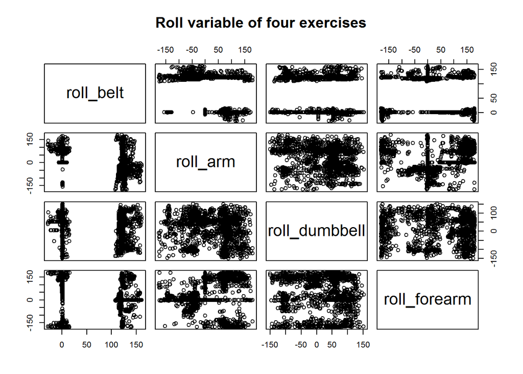

```r
# make plot of variable pairs
pairs(train_sub[,c(1,4,7,10)], main = "Roll variable of four exercises")
```

**Figure 1.**

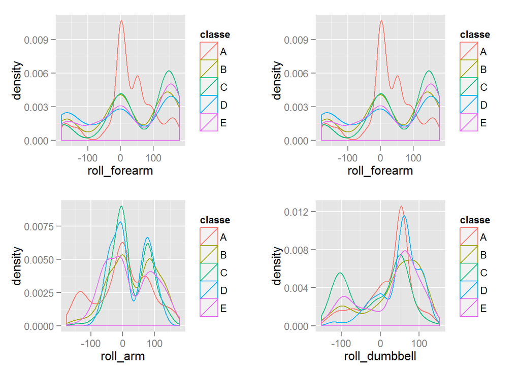

```r
# make plots
p1 = qplot(roll_forearm, colour=classe, data=train_sub, geom='density')
p2 =  qplot(roll_arm, colour=classe, data=train_sub, geom='density')
p3 =  qplot(roll_forearm, colour=classe, data=train_sub, geom='density')
p4 =  qplot(roll_dumbbell, colour=classe, data=train_sub, geom='density')

# function to make multiplots, from R Cookbook (http://www.cookbook-r.com/Graphs/Multiple_graphs_on_one_page_(ggplot2)/)
multiplot(p1,p2,p3,p4, cols = 2)
```

**Figure 2.**

### Data modeling and cross validation

This is the key section where we train the Random Forest model, make predictions for the test data using the fitted model, and then calculate the In and Out of Sample Accuracies for the model. First, let’s train the Random Forest model and calculate the In Sample Accuracy.

```r
# create Random Forest regression tree model
modFit = train(classe ~ .,data = train_sub, method = "rf")
# get accuracy of model
print('Estimate of In Sample Accuracy:')
```

```
## [1] "Estimate of In Sample Accuracy:"
```

```r
max(modFit$results[,2])
```

```
## [1] 0.887551
```

As we see above, the In Sample Accuracy is relatively high at about 89%. Next, we apply the model to predict the classes for the testing group to cross validate. Here, we will predict accuracy for each of the five classes and we find that those are quite high, ranging between 93-98% accuracy, so not too bad!

```r
# make predictions with the model
pred = predict(modFit, test_sub)
# make table of predicted versus actual classe
test_sub$predRight = pred==test_sub$classe
accuracy = table(pred, test_sub$classe)
# get diagonals, the correct predictions
accuracyDiag = diag(accuracy)
# divide each diagonal value by column total, that's the total accuracy
# get accuracy for all of the five classes
for (i in 1:5){
  print(paste("Accuracy of class",uniqClasses[i],":"))
  print(accuracyDiag[i]/sum(accuracy[,i]))
}
```

```
## [1] "Accuracy of class A :"
##         A
## 0.9856631
## [1] "Accuracy of class B :"
##         B
## 0.9368421
## [1] "Accuracy of class C :"
##         C
## 0.9707602
## [1] "Accuracy of class D :"
##         D
## 0.9627329
## [1] "Accuracy of class E :"
##         E
## 0.9834254
```

### Prediction for 20 new subjects

In the final step, we predict the classes for 20 different test subjects using the training model generated above. These will be printed to individual text files to be submitted to the Coursera web page.

```r
# apply the modFit Random Forest model to the 20 test subjects
dataTest_sub = dataTest[,dataCols]
predTest = predict(modFit, dataTest_sub)
# create function to write out answers to individual files
pml_write_files = function(x){
  n = length(x)
  for(i in 1:n){
    filename = paste0("problem_id_",i,".txt")
    write.table(x[i],file=filename,quote=FALSE,row.names=FALSE,col.names=FALSE)
  }
}
# write them out as files
pml_write_files(as.character(predTest))
# print write out predictions for the 20 subjects
print('Predictions for the 20 new subjects')
```

```
## [1] "Predictions for the 20 new subjects"
```

```r
print(predTest)
```

```
##  [1] B A B A A E D B A A B C B A E E A B B B
## Levels: A B C D E
```